# 第四章 利用Rmarkdown生产可重复的报告

邱飞

万里学院

## 为什么要写代码而不是点菜单？

- 数据分析的过程，是个不断探索的过程
- 开始的一个想法，要经过不断的修正才会达到你想要的结果
- 于是，保存你的想法和操作过程就十分重要
- 代码可以保存你的操作过程

## 如何将想法表述和代码操作融为一体？

- 代码是机器的语言
- 而我们数据分析的思路和操作的策略，要用人类的语言（如汉语，英语）来描述
- 传统的处理方式是，在某个编程环境下写代码，然后在某个文字编辑环境（如word）里面写我们的思路。

## 将人类的语言和机器的语言融为一体：文学化编程

- 如何能将编程的代码和我们表达思想的人类语言融为一体，这将大大提高数据分析的效率。
- 文学式编程将你的思路（人类语言表述）和思路的实现（代码语言）融为一体

## 例子：对央行资产负债表扩张速度和cpi之间进行回归（传统方法）

- 假设我们用Eviews来完成这个任务，步骤大致如下
1. 下载人民银行资产负债表规模增速与cpi的数据
2. 将数据导入Eviews软件
3. 进行回归分析
4. 将分析结果和图标等复制到word

## 如果只是一次操作，这个过程看起来还好

[figure not shown]

## 但是，如果你的操作需要后续改进的话

- 突然，尊敬的老师说，你的作业不对，
- 你之前是把cpi作为自变量（X）的，应该把cpi作为因变量（Y）回归。

[figure not shown]

## 如果不是一次性操作

- 于是你要数据再跑一遍
- 然后再把结果和图标复制黏贴到word文档中
- 并且心中在想，老师不会又有新想法吧，到时候我又要复制黏贴调整一次…
- 尤其担心的是，老师在我忘了Eviews点那个键之后，让我再做一次…

## 文学化编程：分析报告和操作代码一体

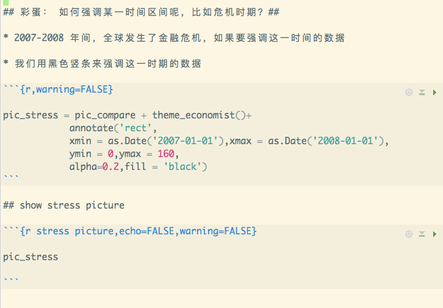

## Markdown语言简介

- markdown是一种简化的标记语言
- 比如在word里，你要将“第四章 分析报告写作”这几个字设为一级标题，你是先选中这段文字，然乎在菜单栏里点一级标题的选项。
- 在markdown里面，你是用两个#号把“第四章 分析报告写作”这几个字围起来就可以了。

`# 第四章 分析报告写作 #`

所谓“标记”语言的含义就在这里，要对文字有特殊的效果，就对其做特殊的标记。

## markdown语法介绍

- 我们课程的原则是：简单，够用
- 所以我么不需要详细的学习mardown语言的语法，虽然它的语言也很简单。
- 更为幸运的是，rstudio里面自带有融合了R语言的mardown文件模版。我们直接使用就可以了。

## 本课程够用的mardown语法

- 一般就如同你在记事本里写字就可以了。
- 如果要新期一段，就空一行输入。
- 输入无序列表的话，就用`*`号开头
- 输入有效列表的话，用`1.`开头

## 编写Rmarkdown脚本

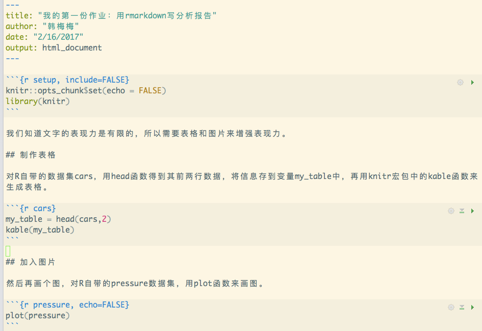

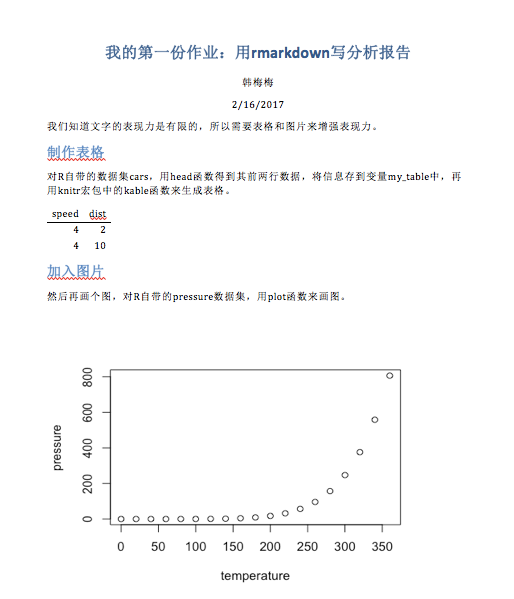